# Summary of Options for Multiple Response Variables (ODK)

Sam Dumble

2023-06-14

## Overview

Analysing multiple response variables is something that we do quite a lot - particularly in the format it comes down from ODK.

I know various members of the team have different strategies for dealing with this - none of the R packages I have found quite do what I want, especially with the added layer from ODK data of having values and having labels. So I have tried to convert my standard workflow into some functions and sharing these to help in the future, and also showing a worked through example of the code.

## Part 1 - The easy option using the functions I have written

If you trust my functions then in order to get some nice output what you will need is an ODK form in xlsx, a dataset created from that ODK form and the script `multi_functions.R`

**Read in the survey and choices sheets from the xlsx form**

```r
survey<-read.xlsx("RHoMIS_croplist.xlsx","survey")
choices<-read.xlsx("RHoMIS_croplist.xlsx","choices")
```

**Read in the data** I have created one version with the multiple column format, and one with the single column format

```r
single_column_example<-read.csv("single_column_export.csv",sep=";")
multiple_column_example<-read.csv("seperate_columns_export.csv",sep=";")
```

```r
source("multi_functions.R")
```

**Identify the column and the labels** I am interested in the multiple select column “crops_all” which uses the list named “crop_list”

```r
labels<-filter(choices,list_name=="crop_list")
```

**From the multiple select data we need the dataframe, the labels, & id_string which identifies the multiple column select**

```r
multi_response_odk(data=multiple_column_example,labelset=labels,id_string="crops_all.")
```

```
## # A tibble: 39 × 7
##    value     label     n per_responses per_respondents N_responses N_respondents
##    <chr>     <chr> <dbl>         <dbl>           <dbl>       <dbl>         <int>
##  1 Maize     Maize    10        0.196           0.435           51            23
##  2 coffee    Coff…     5        0.0980          0.217           51            23
##  3 sorgham   Sorg…     5        0.0980          0.217           51            23
##  4 Cassava   Cass…     4        0.0784          0.174           51            23
##  5 ground_n… Grou…     4        0.0784          0.174           51            23
##  6 other1    Othe…     4        0.0784          0.174           51            23
##  7 Millet    Mill…     3        0.0588          0.130           51            23
##  8 Chili     Chili     2        0.0392          0.0870          51            23
##  9 barley    Barl…     2        0.0392          0.0870          51            23
## 10 cow_pea   Cow …     2        0.0392          0.0870          51            23
## # ℹ 29 more rows
```

**By default I include all values. I can set retain_empty=FALSE to drop the unselected options**

```r
multi_response_odk(data=multiple_column_example,labelset=labels,id_string="crops_all.",retain_empty = FALSE)
```

```
## # A tibble: 17 × 7
##    value     label     n per_responses per_respondents N_responses N_respondents
##    <chr>     <chr> <dbl>         <dbl>           <dbl>       <dbl>         <int>
##  1 Maize     Maize    10        0.196           0.435           51            23
##  2 coffee    Coff…     5        0.0980          0.217           51            23
##  3 sorgham   Sorg…     5        0.0980          0.217           51            23
##  4 Cassava   Cass…     4        0.0784          0.174           51            23
##  5 ground_n… Grou…     4        0.0784          0.174           51            23
##  6 other1    Othe…     4        0.0784          0.174           51            23
##  7 Millet    Mill…     3        0.0588          0.130           51            23
##  8 Chili     Chili     2        0.0392          0.0870          51            23
##  9 barley    Barl…     2        0.0392          0.0870          51            23
## 10 cow_pea   Cow …     2        0.0392          0.0870          51            23
## 11 other2    Othe…     2        0.0392          0.0870          51            23
## 12 soya_bean Soya…     2        0.0392          0.0870          51            23
## 13 tobacco   Toba…     2        0.0392          0.0870          51            23
## 14 chick_pea Chic…     1        0.0196          0.0435          51            23
## 15 no_answer No a…     1        0.0196          0.0435          51            23
## 16 paprika   Papr…     1        0.0196          0.0435          51            23
## 17 tea       Tea       1        0.0196          0.0435          51            23
```

**I could also split by country**

```r
multi_response_odk(data=multiple_column_example,labelset=labels,id_string="crops_all.",retain_empty = FALSE,group="country")
```

```
## # A tibble: 30 × 8
##    country  value     label         n per_responses per_respondents N_responses
##    <chr>    <chr>     <chr>     <dbl>         <dbl>           <dbl>       <dbl>
##  1 Ethiopia other1    Other 1       4        0.235            0.571          17
##  2 Ethiopia Maize     Maize         2        0.118            0.286          17
##  3 Ethiopia Millet    Millet        2        0.118            0.286          17
##  4 Ethiopia coffee    Coffee        2        0.118            0.286          17
##  5 Ethiopia other2    Other 2       2        0.118            0.286          17
##  6 Ethiopia Cassava   Cassava       1        0.0588           0.143          17
##  7 Ethiopia Chili     Chili         1        0.0588           0.143          17
##  8 Ethiopia cow_pea   Cow pea       1        0.0588           0.143          17
##  9 Ethiopia paprika   Paprika       1        0.0588           0.143          17
## 10 Ethiopia soya_bean Soya bean     1        0.0588           0.143          17
## # ℹ 20 more rows
## # ℹ 1 more variable: N_respondents <int>
```

**If I have everything smushed into one column I need the name of that column, and to use the argument `multicolumn` and not `id_string`. Everything else is the same.

```r
multi_response_odk(data=single_column_example,labelset=labels,multicolumn = "crops_all",retain_empty = FALSE,group="country")
```

```
## # A tibble: 30 × 8
##    country  value     label         n per_responses per_respondents N_responses
##    <chr>    <chr>     <chr>     <dbl>         <dbl>           <dbl>       <dbl>
##  1 Ethiopia other1    Other 1       4        0.235            0.571          17
##  2 Ethiopia Maize     Maize         2        0.118            0.286          17
##  3 Ethiopia Millet    Millet        2        0.118            0.286          17
##  4 Ethiopia coffee    Coffee        2        0.118            0.286          17
##  5 Ethiopia other2    Other 2       2        0.118            0.286          17
##  6 Ethiopia Cassava   Cassava       1        0.0588           0.143          17
##  7 Ethiopia Chili     Chili         1        0.0588           0.143          17
##  8 Ethiopia cow_pea   Cow pea       1        0.0588           0.143          17
##  9 Ethiopia paprika   Paprika       1        0.0588           0.143          17
## 10 Ethiopia soya_bean Soya bean     1        0.0588           0.143          17
## # ℹ 20 more rows
## # ℹ 1 more variable: N_respondents <int>
```

**And I can change the language and make a pretty table with a few moves**

```r
multi_response_odk(data=single_column_example,labelset=labels,multicolumn = "crops_all",retain_empty = FALSE,group="country",language="Español.(es)") %>%
  select(country,Crop=label,n,`Percentage of Respondents`=per_respondents) %>%
    mutate(`Percentage of Respondents`=scales::percent(`Percentage of Respondents`))
```

```
## # A tibble: 30 × 4
##    country  Crop         n `Percentage of Respondents`
##    <chr>    <chr>    <dbl> <chr>
##  1 Ethiopia Otro 1       4 57.1%
##  2 Ethiopia Maíz         2 28.6%
##  3 Ethiopia mijo         2 28.6%
##  4 Ethiopia Café         2 28.6%
##  5 Ethiopia Otro 2       2 28.6%
##  6 Ethiopia Mandioca     1 14.3%
##  7 Ethiopia Chile        1 14.3%
##  8 Ethiopia Niébé        1 14.3%
##  9 Ethiopia Pimenton     1 14.3%
## 10 Ethiopia Soya         1 14.3%
## # ℹ 20 more rows
```

**Or pipe into a ggplot**

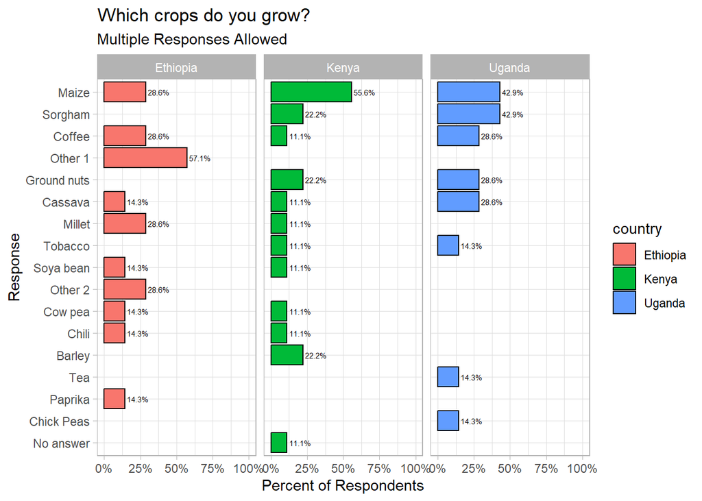

```r
 multi_response_odk(data=single_column_example,labelset=labels,multicolumn = "crops_all",retain_empty = FALSE,group="country") %>%
  #adding some lines so that no answer comes last and other selections are in reversing order with most popular at top
  mutate(y_axis=reorder(label,n,sum,na.rm=T)) %>%
    mutate(y_axis=relevel(y_axis,ref="No answer")) %>%
#then using geom_col and some standard ggplot functions to make it look a bit prettier
  ggplot(aes(y=y_axis,x=per_respondents,fill=country))+
    geom_col(col="black")+
  facet_wrap(~country,nrow=1)+
      geom_text(aes(label=scales::percent(per_respondents)),hjust=-0.1,size=2)+
        scale_x_continuous(labels=scales::percent,limits=c(0,1))+
          xlab("Percent of Respondents")+
            ylab("Response")+
              ggtitle("Which crops do you grow?",subtitle="Multiple Responses Allowed")+
                theme_light()
```

## Part 2 - Doing it yourself and with some extensions that would be harder to turn into functions

Generally my preferred mechanism for dealing with multiple responses is to convert from respondent level to response level (i.e. wide to long) as this makes it easier to then pipe into ggplot or dplyr and play around with the outputs. I also want to identify additional categories to create if there are common “specify other” responses

Ideally the export would be made including the multiple column binaries in the first place as it is much easier to do from that point - but this is not always possible.

I am also assuming that you are exporting ODK data to show the values, not the labels. This means that it is easier to work with and easy to switch up the language in the plots. If you don’t care about this (i.e. you have or need one language only) you can skip those steps in the code below and just look at the labels.

## 1. Converting Single Column To Response Level

```r
single_column_example %>%
  head()
```

```
##   welcome_title metadata_title country              crops_all crops_other1
## 1            NA             NA   Kenya barley cow_pea sorgham
## 2            NA             NA   Kenya    barley Chili coffee
## 3            NA             NA   Kenya           Maize Millet
## 4            NA             NA   Kenya          Cassava Maize
## 5            NA             NA   Kenya          Maize sorgham
## 6            NA             NA   Kenya                tobacco
##   crops_other2 crops_other3 deviceid starttime_auto start_time_user      X_id
## 1                        NA       NA             NA              NA 245724995
## 2                        NA       NA             NA              NA 245725059
## 3                        NA       NA             NA              NA 245725108
## 4                        NA       NA             NA              NA 245725178
## 5                        NA       NA             NA              NA 245725267
## 6                        NA       NA             NA              NA 245725314
##                                 X_uuid   X_submission_time X_validation_status
```

[output cut: 20 more lines]

### Step 1.1 Split the multiple response into multiple variables

```r
single_column_example %>%
  separate(crops_all,into=paste0("crop_selected",1:(1+max(str_count(.$crops_all," ")))))
```

```
##    welcome_title metadata_title  country crop_selected1 crop_selected2
## 1             NA             NA    Kenya         barley            cow
## 2             NA             NA    Kenya         barley          Chili
## 3             NA             NA    Kenya          Maize         Millet
## 4             NA             NA    Kenya        Cassava          Maize
## 5             NA             NA    Kenya          Maize        sorgham
## 6             NA             NA    Kenya        tobacco           <NA>
## 7             NA             NA    Kenya         ground           nuts
## 8             NA             NA    Kenya         ground           nuts
## 9             NA             NA    Kenya             no         answer
## 10            NA             NA Ethiopia           soya           bean
## 11            NA             NA Ethiopia          Chili         other1
## 12            NA             NA Ethiopia        Cassava         other1
## 13            NA             NA Ethiopia         coffee           <NA>
## 14            NA             NA Ethiopia         coffee          Maize
```

[output cut: 129 more lines]

### Step 1.3 Convert into response level

```r
single_column_example %>%
  separate(crops_all,into=paste0("crop_selected",1:(1+max(str_count(.$crops_all," "))))) %>%
    select(X_uuid,contains("crop_selected"),contains("crops_other")) %>%
      pivot_longer(contains("crop_selected"),names_to = "selection",values_to = "crop",values_drop_na = TRUE)
```

```
## # A tibble: 61 × 6
##    X_uuid                 crops_other1 crops_other2 crops_other3 selection crop
##    <chr>                  <chr>        <chr>        <lgl>        <chr>     <chr>
##  1 7de31e17-a2e4-4c09-be… ""           ""           NA           crop_sel… barl…
##  2 7de31e17-a2e4-4c09-be… ""           ""           NA           crop_sel… cow
##  3 7de31e17-a2e4-4c09-be… ""           ""           NA           crop_sel… pea
##  4 7de31e17-a2e4-4c09-be… ""           ""           NA           crop_sel… sorg…
##  5 8d4a7507-acc8-49c9-b6… ""           ""           NA           crop_sel… barl…
##  6 8d4a7507-acc8-49c9-b6… ""           ""           NA           crop_sel… Chili
##  7 8d4a7507-acc8-49c9-b6… ""           ""           NA           crop_sel… coff…
##  8 efd25b03-dee6-43fb-9d… ""           ""           NA           crop_sel… Maize
##  9 efd25b03-dee6-43fb-9d… ""           ""           NA           crop_sel… Mill…
## 10 796326e9-b95f-4025-a7… ""           ""           NA           crop_sel… Cass…
## # ℹ 51 more rows
```

### Step 1.3 Merge in labels

```r
single_column_example %>%
  separate(crops_all,sep=" ",into=paste0("crop_selected",1:(1+max(str_count(.$crops_all," "))))) %>%
    select(X_uuid,contains("crop_selected"),contains("crops_other")) %>%
      pivot_longer(contains("crop_selected"),names_to = "selection",values_to = "crop",values_drop_na = TRUE) %>%
    select(-selection) %>%
        inner_join(
          filter(choices,list_name=="crop_list"),by=c("crop"="name"))->long_multiresponses_from_single_column
```

## 2. Converting Multiple Column To Response Level

Aim now is to get that same format of data from the multiple binary variable format as well

```r
multiple_column_example %>%
    select(X_uuid,contains("crops_all."),contains("crops_other")) %>%
      pivot_longer(contains("crops_all"),names_to = "crop",values_to = "exist") %>%
  filter(exist==1) %>%
  mutate(crop=str_remove(crop,"crops_all.")) %>%
  select(-exist) %>%
        inner_join(
          filter(choices,list_name=="crop_list"),by=c("crop"="name"))->long_multiresponses_from_multiple_column
```

At this point the two datasets should be identical to each other and we can move on to the next step

## 3. Calculate Summaries

For purpose of summaries “no response” is not the same as the other responses. Exact choices on how to deal with it may vary by context - but generally it should be accounted for at respondent level, but not at response level Similarly if a respond did not select any options (if this was allowed by the logic of the form)

```r
long_multiresponses_from_multiple_column %>%
  filter(crop!="no_answer")
```

```
## # A tibble: 50 × 19
##    X_uuid                 crops_other1 crops_other2 crops_other3 crop  list_name
##    <chr>                  <chr>        <chr>        <lgl>        <chr> <chr>
##  1 7de31e17-a2e4-4c09-be… ""           ""           NA           barl… crop_list
##  2 7de31e17-a2e4-4c09-be… ""           ""           NA           cow_… crop_list
##  3 7de31e17-a2e4-4c09-be… ""           ""           NA           sorg… crop_list
##  4 8d4a7507-acc8-49c9-b6… ""           ""           NA           barl… crop_list
##  5 8d4a7507-acc8-49c9-b6… ""           ""           NA           Chili crop_list
##  6 8d4a7507-acc8-49c9-b6… ""           ""           NA           coff… crop_list
##  7 efd25b03-dee6-43fb-9d… ""           ""           NA           Maize crop_list
##  8 efd25b03-dee6-43fb-9d… ""           ""           NA           Mill… crop_list
##  9 796326e9-b95f-4025-a7… ""           ""           NA           Cass… crop_list
## 10 796326e9-b95f-4025-a7… ""           ""           NA           Maize crop_list
## # ℹ 40 more rows
## # ℹ 13 more variables: `label::English.(en)` <chr>,
## #   `label::Français.(fr)` <chr>, `label::Español.(es)` <chr>,
## #   `label::हिंदी.(hi)` <chr>, `label::عربى(ar)` <chr>,
## #   `label::Kiswahili.(sw)` <chr>, `label::ខ្មែរ.(km)` <chr>,
## #   `label::Kinyarwanda.(rw)` <chr>, `label::Vietnamese.(vi)` <chr>,
## #   region <dbl>, sublocation <dbl>, sublocation2 <dbl>, village <dbl>
```

```r
overall_respondents <- multiple_column_example %>%
  summarise(N_respondents=n()) %>%
  mutate(Group=1)



long_multiresponses_from_multiple_column %>%
  mutate(N_responses=n()) %>%
    group_by(crop,across(contains("label::")),N_responses) %>%
      summarise(n=n()) %>%
       mutate(Group=1)%>%
           full_join(overall_respondents) %>%
              mutate(per_responses=n/N_responses,
                     per_respondents=n/N_respondents) %>%
  ungroup()->summary_data
```

[output not shown]

Can then pick one language and convert this into a pretty table:

```r
summary_data %>%
  arrange(desc(n)) %>%
  mutate("% of Respondents"=scales::percent(per_respondents),
         "% of Responses"=scales::percent(per_responses)) %>%
  select(Crop=`label::English.(en)`,n,"% of Respondents","% of Responses")
```

```
## # A tibble: 17 × 4
##    Crop            n `% of Respondents` `% of Responses`
##    <chr>       <int> <chr>              <chr>
##  1 Maize          10 43.5%              19.6%
##  2 Coffee          5 21.7%              9.8%
##  3 Sorgham         5 21.7%              9.8%
##  4 Cassava         4 17.4%              7.8%
##  5 Ground nuts     4 17.4%              7.8%
##  6 Other 1         4 17.4%              7.8%
##  7 Millet          3 13.0%              5.9%
##  8 Chili           2 8.7%               3.9%
##  9 Barley          2 8.7%               3.9%
## 10 Cow pea         2 8.7%               3.9%
## 11 Other 2         2 8.7%               3.9%
## 12 Soya bean       2 8.7%               3.9%
## 13 Tobacco         2 8.7%               3.9%
## 14 Chick Peas      1 4.3%               2.0%
## 15 No answer       1 4.3%               2.0%
## 16 Paprika         1 4.3%               2.0%
## 17 Tea             1 4.3%               2.0%
```

Si te gustas este table en espanol es muy facil tambien - solo necisitas un poco modificacion:

```r
summary_data %>%
  arrange(desc(n)) %>%
  mutate("% de Encuestadas"=scales::percent(per_respondents),
         "% de Repuestas"=scales::percent(per_responses)) %>%
  select(Cultivo=`label::Español.(es)`,n,"% de Encuestadas","% de Repuestas")
```

```
## # A tibble: 17 × 4
##    Cultivo              n `% de Encuestadas` `% de Repuestas`
##    <chr>            <int> <chr>              <chr>
##  1 Maíz                10 43.5%              19.6%
##  2 Café                 5 21.7%              9.8%
##  3 Maicillo, sorgo      5 21.7%              9.8%
##  4 Mandioca             4 17.4%              7.8%
##  5 Maní, cacahuetes     4 17.4%              7.8%
##  6 Otro 1               4 17.4%              7.8%
##  7 mijo                 3 13.0%              5.9%
##  8 Chile                2 8.7%               3.9%
##  9 Cebada               2 8.7%               3.9%
## 10 Niébé                2 8.7%               3.9%
## 11 Otro 2               2 8.7%               3.9%
## 12 Soya                 2 8.7%               3.9%
## 13 tabaco               2 8.7%               3.9%
## 14 Garbanzos            1 4.3%               2.0%
## 15 Sin respuesta        1 4.3%               2.0%
## 16 Pimenton             1 4.3%               2.0%
## 17 Té                   1 4.3%               2.0%
```

### Split by group

The Group=1 stage is a bit clunky, but means the code can be more or less kept the same if you want to split this by country

For human readable table better to pick just one ‘sort’ of percent and have columns by country

Moving from the start - need to make sure you carry through the grouping variable (in this case Country):

```r
multiple_column_example %>%
    select(X_uuid,contains("crops_all."),contains("crops_other"),country) %>%
      pivot_longer(contains("crops_all"),names_to = "crop",values_to = "exist") %>%
  filter(exist==1) %>%
  mutate(crop=str_remove(crop,"crops_all.")) %>%
  select(-exist) %>%
        inner_join(
          filter(choices,list_name=="crop_list"),by=c("crop"="name"))->long_multiresponses_from_multiple_column_grouped


overall_respondents_bygroup <- multiple_column_example %>%
  group_by(country) %>%
  summarise(N_respondents=n())



long_multiresponses_from_multiple_column_grouped %>%
    group_by(country) %>%
  mutate(N_responses=n()) %>%
  ungroup() %>%
    group_by(crop,country,across(contains("label::")),N_responses) %>%
      summarise(n=n()) %>%
        ungroup() %>%
           full_join(overall_respondents_bygroup,by="country") %>%
              mutate(per_responses=n/N_responses,
                     per_respondents=n/N_respondents) %>%
  ungroup()->summary_data_grouped
```

[output not shown]

```r
summary_data_grouped %>%
  mutate(Crop=reorder(`label::English.(en)`,per_respondents,mean)) %>%
  arrange(country,desc(Crop)) %>%
  mutate("% of Respondents"=scales::percent(per_respondents),
         "% of Responses"=scales::percent(per_responses)) %>%
  select(Country=country,Crop,n,"% of Respondents","% of Responses")
```

```
## # A tibble: 30 × 5
##    Country  Crop          n `% of Respondents` `% of Responses`
##    <chr>    <fct>     <int> <chr>              <chr>
##  1 Ethiopia Other 1       4 57.1%              23.53%
##  2 Ethiopia Maize         2 28.6%              11.76%
##  3 Ethiopia Other 2       2 28.6%              11.76%
##  4 Ethiopia Coffee        2 28.6%              11.76%
##  5 Ethiopia Millet        2 28.6%              11.76%
##  6 Ethiopia Cassava       1 14.3%              5.88%
##  7 Ethiopia Paprika       1 14.3%              5.88%
##  8 Ethiopia Soya bean     1 14.3%              5.88%
##  9 Ethiopia Cow pea       1 14.3%              5.88%
## 10 Ethiopia Chili         1 14.3%              5.88%
## # ℹ 20 more rows
```

```r
summary_data_grouped %>%
  mutate(Crop=reorder(`label::English.(en)`,n,sum,na.rm=T)) %>%
  arrange(country,desc(Crop)) %>%
  mutate("%"=scales::percent(per_respondents)) %>%
  select(Country=country,Crop,"%") %>%
  pivot_wider(id_cols=Crop,names_from = Country,values_from="%",values_fill="0.0%" )
```

```
## # A tibble: 17 × 4
##    Crop        Ethiopia Kenya Uganda
##    <fct>       <chr>    <chr> <chr>
##  1 Maize       28.6%    55.6% 42.9%
##  2 Coffee      28.6%    11.1% 28.6%
##  3 Other 1     57.1%    0.0%  0.0%
##  4 Cassava     14.3%    11.1% 28.6%
##  5 Millet      28.6%    11.1% 0.0%
##  6 Soya bean   14.3%    11.1% 0.0%
##  7 Other 2     28.6%    0.0%  0.0%
##  8 Cow pea     14.3%    11.1% 0.0%
##  9 Chili       14.3%    11.1% 0.0%
## 10 Paprika     14.3%    0.0%  0.0%
## 11 Sorgham     0.0%     22.2% 42.9%
## 12 Ground nuts 0.0%     22.2% 28.6%
## 13 Tobacco     0.0%     11.1% 14.3%
## 14 Barley      0.0%     22.2% 0.0%
## 15 No answer   0.0%     11.1% 0.0%
## 16 Tea         0.0%     0.0%  14.3%
## 17 Chick Peas  0.0%     0.0%  14.3%
```

### Plots

Easy enough to pipe the output from the previous steps into some barplots. Can use re-order to place the responses in descending order of popularity and then relevel to place any “non-answer” answers at the bottom

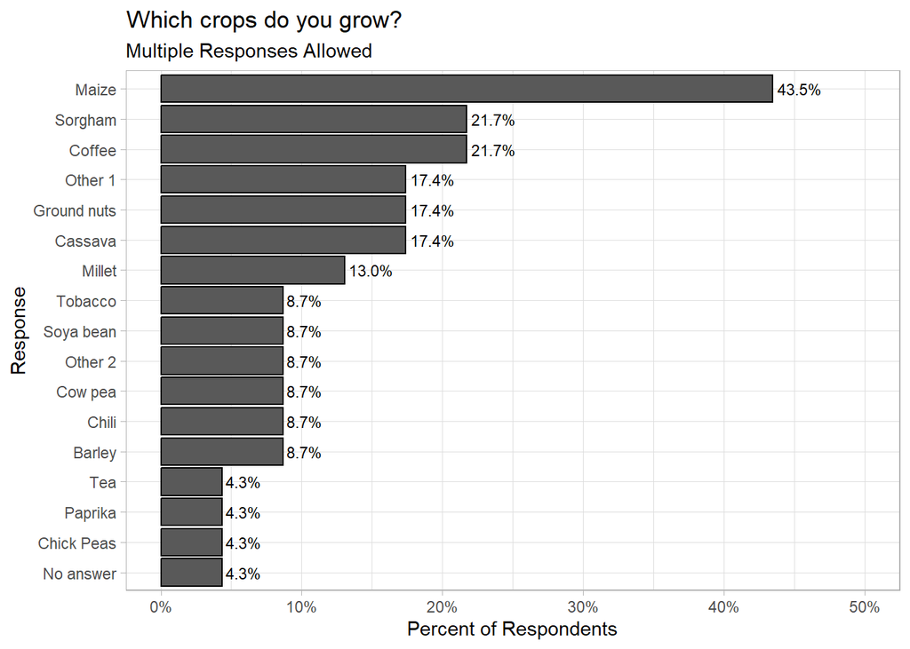

```r
summary_data %>%
  mutate(y_axis=reorder(`label::English.(en)`,per_respondents,mean)) %>%
    mutate(y_axis=relevel(y_axis,ref="No answer")) %>%
  ggplot(aes(y=y_axis,x=per_respondents))+
    geom_col(col="black")+
      geom_text(aes(label=scales::percent(per_respondents)),hjust=-0.1,size=3)+
        scale_x_continuous(labels=scales::percent,limits=c(0,0.5))+
          xlab("Percent of Respondents")+
            ylab("Response")+
              ggtitle("Which crops do you grow?",subtitle="Multiple Responses Allowed")+
                theme_light()
```

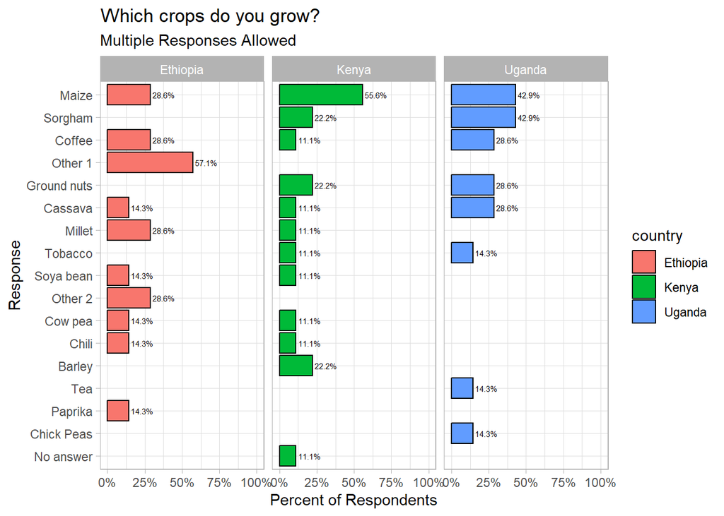

```r
summary_data_grouped %>%
  mutate(y_axis=reorder(`label::English.(en)`,n,sum,na.rm=T)) %>%
    mutate(y_axis=relevel(y_axis,ref="No answer")) %>%
  ggplot(aes(y=y_axis,x=per_respondents,fill=country))+
    geom_col(col="black")+
  facet_wrap(~country,nrow=1)+
      geom_text(aes(label=scales::percent(per_respondents)),hjust=-0.1,size=2)+
        scale_x_continuous(labels=scales::percent,limits=c(0,1))+
          xlab("Percent of Respondents")+
            ylab("Response")+
              ggtitle("Which crops do you grow?",subtitle="Multiple Responses Allowed")+
                theme_light()
```

## Dealing With Others

Other 1 and Other 2 in this example are not really real categories. From the “long data format” this is easy enough to account for IF the other text has been cleaned.

Can have a list of “acceptable” others which will then populate the same as others. But data cleaning before this step definitely needed. Only really worthwhile doing this in one language (since freetext is going to be harder to make multi-lingual) so this is very much assuming that cleaning is done into the language being selected

```r
multiple_column_example %>%
    select(X_uuid,contains("crops_all."),contains("crops_other"),country) %>%
      pivot_longer(contains("crops_all"),names_to = "crop",values_to = "exist") %>%
  filter(exist==1) %>%
  mutate(crop=str_remove(crop,"crops_all.")) %>%
  select(-exist) %>%
        inner_join(
          filter(choices,list_name=="crop_list"),by=c("crop"="name"))->long_multiresponses_from_multiple_column_grouped


overall_respondents_bygroup <- multiple_column_example %>%
  group_by(country) %>%
  summarise(N_respondents=n())



long_multiresponses_from_multiple_column_grouped %>%
  mutate(combined_label=ifelse(!crop%in%c("other1","other2","other3"),`label::English.(en)`,
                               ifelse(crop=="other1",
                                      ifelse(crops_other1%in%c("Tef","Enset"),crops_other1,"Other"),
                                        ifelse(crop=="other2",    ifelse(crops_other2%in%c("Tef","Enset"),crops_other2,"Other"),
                                          ifelse(crops_other2%in%c("Tef","Enset"),crops_other3,"Other")
                                      )))) %>%
    group_by(country) %>%
  mutate(N_responses=n()) %>%
  ungroup() %>%
    group_by(country,combined_label,N_responses) %>%
      summarise(n=n()) %>%
        ungroup() %>%
           full_join(overall_respondents_bygroup,by="country") %>%
              mutate(per_responses=n/N_responses,
                     per_respondents=n/N_respondents) %>%
  ungroup()->summary_data_grouped_others
```

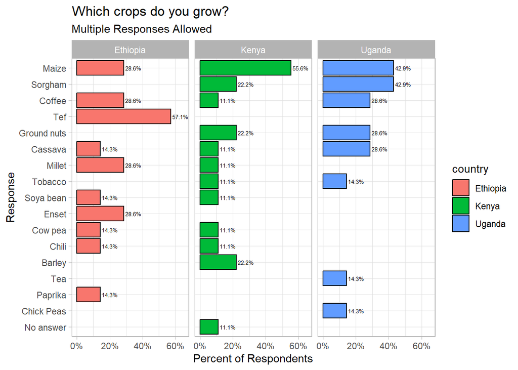

```r
summary_data_grouped_others %>%
  mutate(y_axis=reorder(combined_label,n,sum,na.rm=T)) %>%
    mutate(y_axis=relevel(y_axis,ref="No answer")) %>%
  ggplot(aes(y=y_axis,x=per_respondents,fill=country))+
    geom_col(col="black")+
  facet_wrap(~country,nrow=1)+
      geom_text(aes(label=scales::percent(per_respondents)),hjust=-0.1,size=2)+
        scale_x_continuous(labels=scales::percent,limits=c(0,0.65))+
          xlab("Percent of Respondents")+
            ylab("Response")+
              ggtitle("Which crops do you grow?",subtitle="Multiple Responses Allowed")+
                theme_light()
```